# Лабораторная работа №12

Настройки сети в Linux

Эзиз Хатамов

Российский университет дружбы народов, Москва, Россия

1 ноября 2025

# Цель работы

## Основная цель

Получить практические навыки настройки сетевых параметров и управления соединениями в ОС Linux.

# Ход выполнения работы

## Проверка конфигурации сети

- Команда **ip -s link** отобразила активные интерфейсы и статистику пакетов.
- Интерфейс **enp0s3** имеет состояние **UP** и MAC-адрес `08:00:27:84:d7:ba`.
- Проверка командой **ping 8.8.8.8** показала успешное подключение к Интернету.

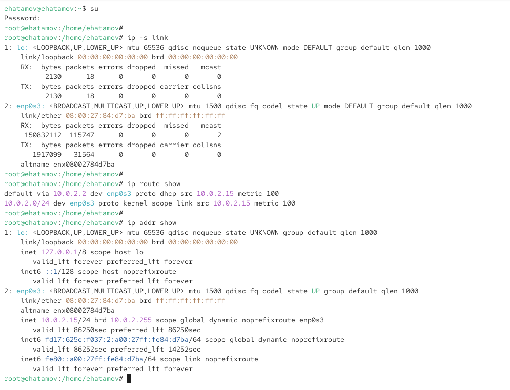

Проверка конфигурации сети

## Анализ маршрутов и адресов

- **ip route show** — основной шлюз **10.0.2.2**.
- **ip addr show** — IPv4-адрес интерфейса **10.0.2.15/24**.
- Дополнительно добавлен адрес **10.0.0.10/24** для **enp0s3**.

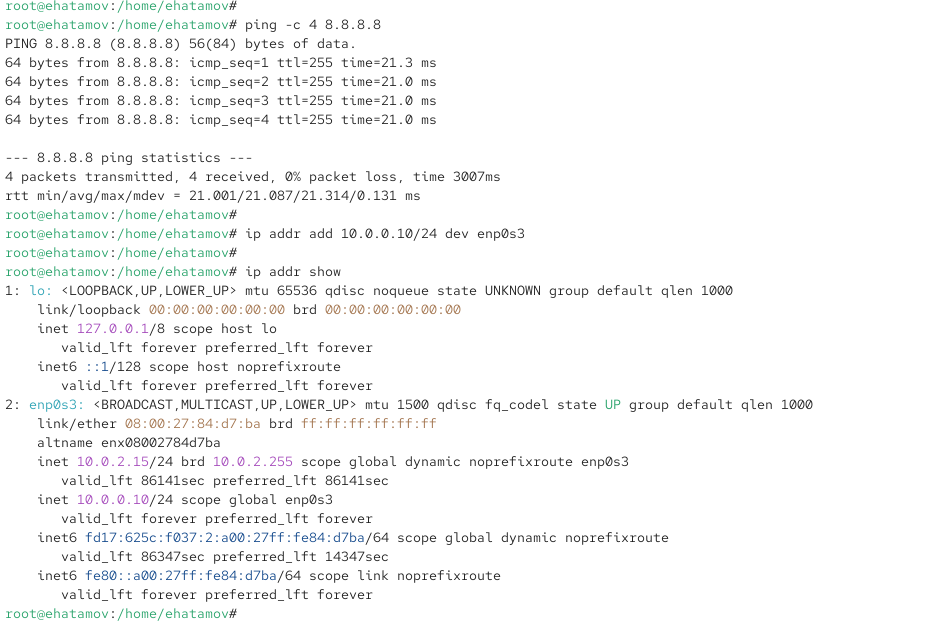

Отображение маршрутов и IP-адресов

## Сравнение ip и ifconfig

- Утилита **ip** предоставляет больше данных, чем **ifconfig**.
- Обе показывают состояние, MAC, IP, статистику пакетов.

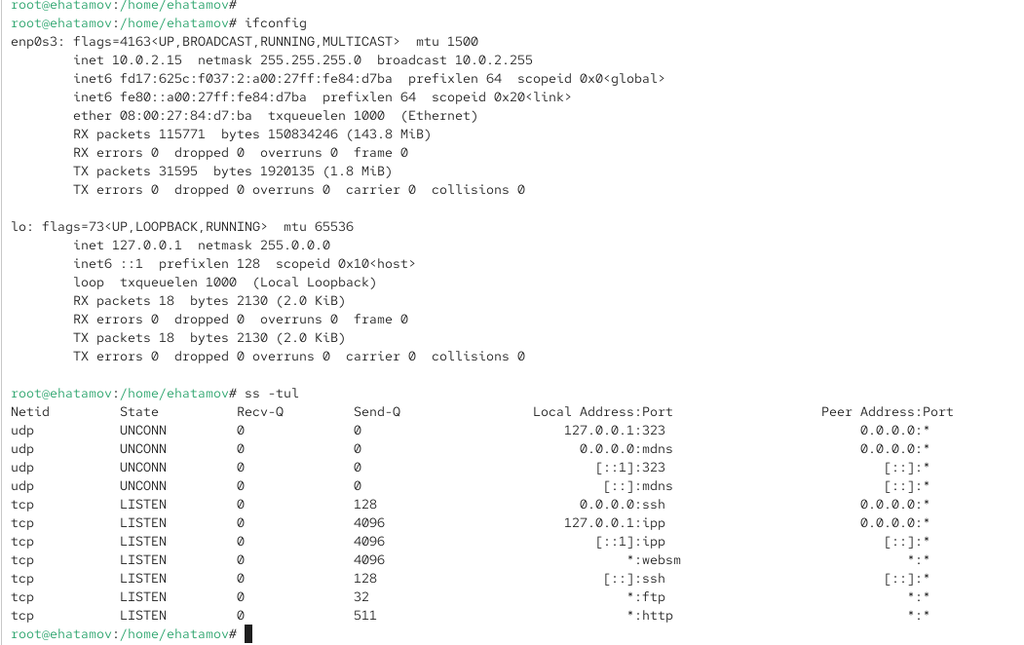

Сравнение вывода ip и ifconfig

## Проверка открытых портов

- Команда **ss -tul** показала активные порты:

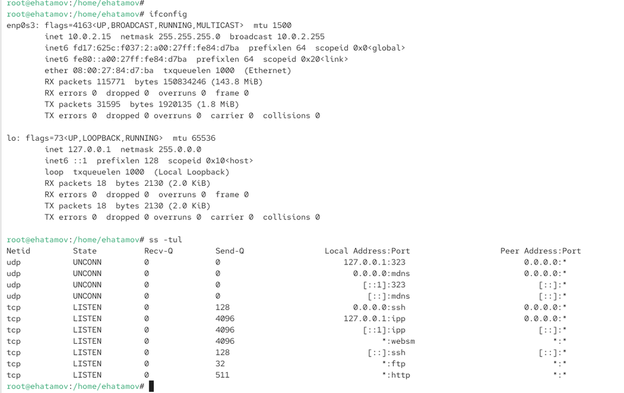

Проверка открытых портов

## Управление соединениями через nmcli

- Просмотр соединений: **nmcli connection show**
- Созданы подключения:
  - **dhcp** — автоматическое получение параметров
  - **static** — ручная настройка IP: `10.0.0.10/24`, шлюз `10.0.0.1`

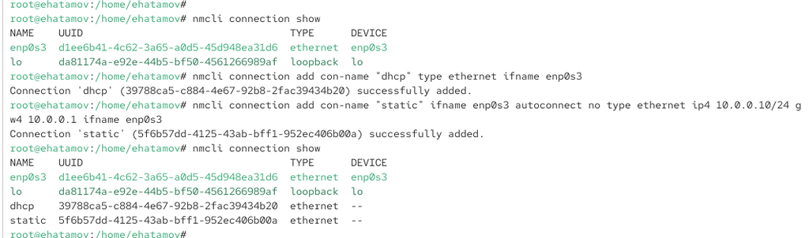

Создание и просмотр сетевых соединений

## Переключение соединений

- Активация статического профиля: **nmcli connection up “static”**
- Проверено изменение IP-адреса до **10.0.0.10**
- Возврат к DHCP-подключению: **nmcli connection up “dhcp”**

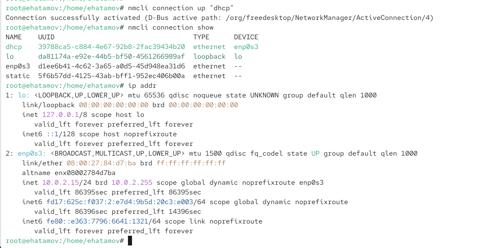

Переключение между соединениями

## Изменение параметров через nmcli

- Отключено автоподключение профиля **static**.
- Добавлены DNS-серверы: **10.0.0.10** и **8.8.8.8**.
- Изменён IP: **10.0.0.20/24**, добавлен второй — **10.20.30.40/16**.

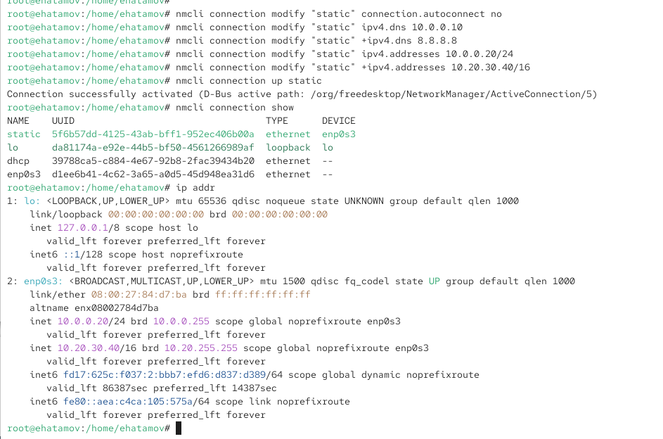

Изменение параметров соединения

## Просмотр конфигурации через nmtui

- В **nmtui** отображены параметры профиля **static**:
  - IP: **10.0.0.20/24** и **10.20.30.40/16**
  - DNS: **10.0.0.10**, **8.8.8.8**
  - Шлюз: **10.0.0.1**

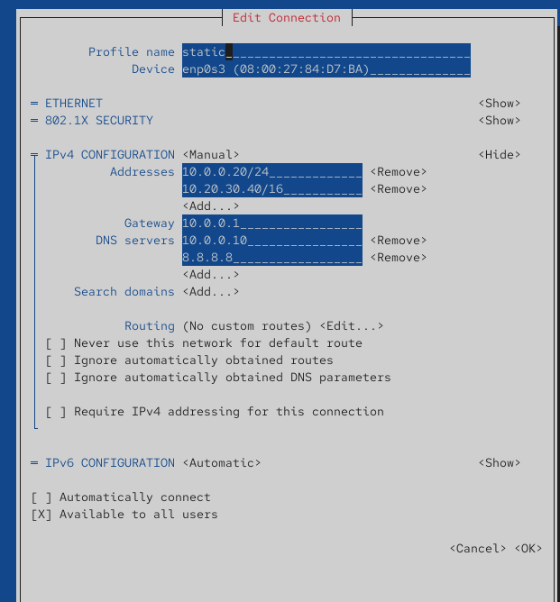

Настройки профиля static в nmtui

## Проверка в графическом интерфейсе

- Параметры:
  - IP — **10.0.0.20**, **10.20.30.40**
  - DNS — **10.0.0.10**, **8.8.8.8**
  - Шлюз — **10.0.0.1**

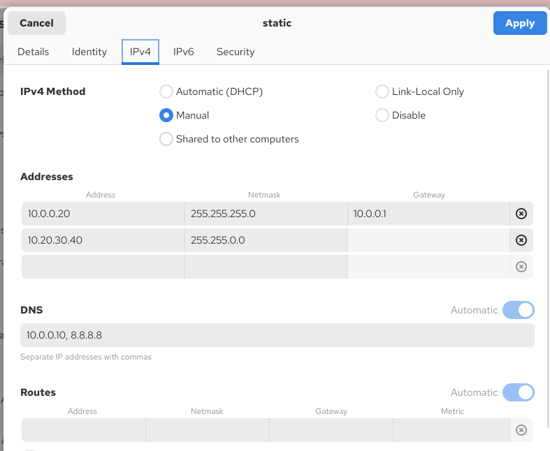

Настройки сети в GUI

## Проверка профиля DHCP

- Профиль **dhcp** получил параметры автоматически

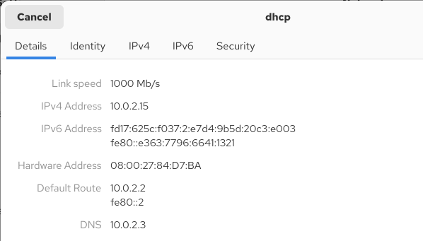

Просмотр параметров DHCP-подключения

# Итоги работы

## Вывод

- Освоены команды **ip**, **ss**, **nmcli**, **nmtui**.
- Настроены как динамические, так и статические IP-подключения.
- Получены практические навыки управления сетевыми параметрами Linux.